# For Students

## Office Hours

My office is in 237 Walker Hall. Office hours for the fall are MWF 10:00 a.m. to 11:30 a.m. Students may click on [book now](https://arnholtat.youcanbook.me/) to schedule an appointment.

| Time | Monday | Tuesday | Wednesday | Thursday | Friday |
| --- | --- | --- | --- | --- | --- |
| 10:00-11:30 | Office | MAT 5500 | Office | MAT 5500 | Office |
| 1:00-1:50 | STT 3850 | STT 3850 | STT 3850 | STT 3850 | Research |
| 2:00-2:50 | STT 3850 | STT 3850 | STT 3850 | STT 3850 | Research |
| 3:30-4:45 | Research | STT 3530 | Research | STT 3530 | Colloquia |

Walker Hall

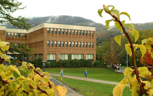

Use the leaflet map below to find Walker Hall.

[interactive chart not shown]

## Important Dates and Times

- [Academic calendar](https://registrar.appstate.edu/calendars-schedules/academic-calendar)
- [Exam schedule](https://registrar.appstate.edu/calendars-schedules/exam-schedule-0)
- [Registration Access Times](https://registrar.appstate.edu/students/registration-classes/early-registration-access)

## Writing Resources

Please visit [The University Writing Center](http://writingcenter.appstate.edu/) for resources to help you with your papers and other writing pursuits.

## Disability Services and Test Proctoring

“Appalachian State University is committed to making reasonable accommodations for individuals with documented qualifying disabilities in accordance with the Americans with Disabilities Act of 1990, and Section 504 of the Rehabilitation Act of 1973. If you have a disability and may need reasonable accommodations in order to have equal access to the University’s courses, programs and activities, please contact the Office of Disability Services (828.262.3056 or http://ods.appstate.edu).Once registration is complete, individuals will meet with ODS staff to discuss eligibility and appropriate accommodations.”

## Courses I Teach

- Click the Teaching Tab

## Computing Resources

- Click the Resources Tab